# lab

**Convex and Distributed Optimization Lab**  
**MSIAM — Université Grenoble Alpes — 2018/2019**  
**Lecturers: Jérôme Malick, Yassine Laguel, Sélim Chraibi**

### Authors: Begatim Bytyqi, Ilia Riabov , Ebba Ekblom

```python
# Automatic reload of local libraries
%load_ext autoreload
%autoreload 2
%reload_ext autoreload
%matplotlib inline
```

```
The autoreload extension is already loaded. To reload it, use:
  %reload_ext autoreload
```

> **I. Introduction**  
> **II. The optimization problem**  
> **III. Implementing the solvers**  
> GD (Gradient descent))  
> SGD (Stochastic Gradient Descent))  
> SAGA (Stochastic Average Gradient "Amélioré"))  
> SVRG (Stochastic Variance Reduced Gradient))  
> Comparison  
> **IV. Regularization**  
> **V. Further development**

In this lab, we will implement optimization algorithms that we have've studied in class and use them to fit a logistic regression classification model.

Report in groups of 1 to 3 students.  
**Due date:** Monday, January 6, 2019 (before midnight).  
**Send to:** cdo.grenoble@gmail.com

# I. Introduction

We consider the [Student Performance](http://archive.ics.uci.edu/ml/datasets/Student+Performance) dataset. This dataset contains student demographic, social, school-related features, how many classes they've missed, etc.

The goal we give ourselves is to predict whether a student will pass (final grade > 12).

We denote $A \in \mathcal{M}_{n,d}(\mathbb{R})$ the feature matrix, containing $n$ samples with $d$ features, and $b \in \{-1,1\}^n$ the label vector where $-1$ encodes `fail` and $1$ encodes `pass`.

The data has already been preprocessed. You can check `\lib\datasets.py` if you're curious, otherwise, you can just use the following to load your dataset:

```python
from lib.datasets import load_student_data


A_train, A_test, b_train, b_test = load_student_data('data/student-mat.csv', split=0.25)
```

**Question:**

- Import [sklearn.linear_model.LogisticRegression](https://scikit-learn.org/stable/modules/generated/sklearn.linear_model.LogisticRegression.html) .
- Create an instance of sklearn's logistic regression classifiers with SAGA as its solver.
- Fit the classifier on the training data and compute the score of the fitted model on the test set.

```python
from sklearn.linear_model import LogisticRegression
from sklearn.metrics import accuracy_score

model = LogisticRegression(solver="sag")

model.fit(A_train,b_train)

predictions = model.predict(A_test)

accuracy_score(predictions,b_test)
```

```
0.8787878787878788
```

# II. The optimization problem

Logistic regression consists in finding the parameter $x \in \mathbb{R}^d$ that best fits: $$ b_i = \begin{cases} \phantom{-}1 \ \textrm{ if }\ \langle a_{i}, x\rangle \ge 0 \\ -1 \ \textrm{ if }\ \langle a_{i}, x\rangle < 0 \end{cases} $$ for all the samples $i$ of the training set (where $a_i$ is the $i^{th}$ line of $A$ and $b_i$ the $i^{th}$ element of $b$). To measure this fit, logistic regression chooses the following loss:

$$ \textrm{LogisticLoss}(b_i, \left\langle a_{i}, x\right\rangle ) = \log \left(1+\exp \left(-b_{i}\left\langle a_{i}, x\right\rangle\right)\right) $$

The corresponding optimization problem we will consider is the following:

Minimization of the empirical risk $f$ of the $L_2$-regularized logistic regression model, on the dataset $(A_{\textrm{train}},b_{\textrm{train}})$: $$ \begin{aligned} \textrm{min}_{x\in \mathbb{R}^d} \ f(x) \ &= \ \textrm{min}_{x\in \mathbb{R}^d} \ \frac{1}{n_{\textrm{train}}} \sum_{i=1}^{n_{\textrm{train}}} f_i(x) \\ &= \ \textrm{min}_{x\in \mathbb{R}^d}\frac{1}{n_{\textrm{train}}} \sum_{i=1}^{n_{\textrm{train}}} \textrm{LogisticLoss}(b_i, \left\langle a_{i}, x\right\rangle ) + \frac{l_2}{2}\|x\|^{2}_2, \end{aligned} $$ where $l_2 \ge 0$ is the $L_2$ regularization coefficient.

To simplify the notation, we'll stop indexing $A$, $b$ and $n$ with "$\textrm{train}$" in the following.

**Question:** $f$ is $\mu$-strongly convex.

- Give a lower bound on $\mu$.

> **Answer:** For function f to be $\mu$ strongly convex,we should have that the function $ f - \frac{\mu}{2}\|x\|^2$ is convex, which means $\frac{1}{m}\sum_{i=1}^{m} f_i - \frac{(\mu - l_2)}{2} \|x\|^2$ to be convex and $\mu - l_2 \geq 0$. We prove that the functions $log(1 + e^{-x}$ and $\|x\|_2^2$ are convex: Consider the function $f(x) = log(1 + e^{-x})$, its first derivative is $f'(x) = \frac{1}{1+e^x}$, and its second derivative is $f"(x) = \frac{e^x}{\left(1 + e^x\right)^2}$. Since $f"(x) \geq 0 $, $\forall x$ we have that the function $f(x) = log(1 + e^{-x})$ is convex. THe conviexity of the funxtion $\|x\|_2^2$ follows from the convextiy of the function $x^2$ and $\|x\|$, as a composition of these two functions.
> Since the functions $log(1 + e^{-x})$, and $\|x\|^2$ are convex, so is their linear combination, hence all what is left is the non-negativity condition which implies the lower bound on $\mu$: $$\mu \geq l_2$$

**Question:** Denote $\lambda_{\max}$ the largest eigenvalue of the real symmetric matrix $AA^T$.

- Prove that $\lambda_{\max}(\nabla^2 f_i) \le \lambda_{\max}(\frac{a_i a_i^T}{4} + l_2 I_d)$
- Prove that $\lambda_{\max}(a_i a_i^T) \le \|a_i\|^2_2$

#### Quesiton 1

> **Answer:** So $f_i$ is definet as $f_i := log(1 + exp(-b_i \langle a_i, x\rangle>)) + \frac{l_2}{2} \|x\|_2^2$ from here its obvious that the gradient of this function is given by:

$$\nabla f_i = \frac{-b_i a_i }{1 + e^{b_i \langle a_i,x \rangle}} + l_2 x$$

> Since $b_i^2 = 1$, for the Hessian we get: $$ \Delta f_i = \frac{b_i^2 a_i a_i^T e^{b_i \langle a_i, x \rangle}}{\left(1 + e^{b_i \langle a_i, x \rangle}\right)^2} + l_2 I = \frac{a_i a_i^T e^{b_i \langle a_i, x \rangle}}{\left(1 + e^{b_i \langle a_i, x \rangle}\right)^2} + l_2 I \leq \frac{a_i a_i^T}{4} + l_2 I$$ The last equality is reasoned like follows: Since $b_i \langle a_i , x_i\rangle$ is always positive (from the definiton) we have that $e^{b_i \langle a_i, x \rangle} \geq 1 $ .Hence since function the $x^2$ is an increasing funtion on $[0, +\infty]$ we have that $\left(1 + e^{b_i \langle a_i ,x \rangle} \right)^2 \geq 4$ so finally $\frac{ e^{b_i \langle a_i, x \rangle}}{\left(1 + e^{b_i \langle a_i, x \rangle}\right)^2} \leq \frac{1}{4}$

> We come back again to the inequality: $$\nabla f_i = \frac{-b_i a_i }{1 + e^{b_i \langle a_i,x \rangle}} + l_2 x$$ By multiplying by left(right) with $x^T$($x$) where $x \in \mathrm{R}^n$ we get an equivalent inequality: $$x^T\nabla f_i x \leq x^T \left(\frac{a_i a_i^T}{4} + l_2 I_d\right) x$$ Which is equivalent to: $$\lambda_{\max}(\nabla^2 f_i) \leq \lambda_{\max}(\frac{a_i a_i^T}{4} + l_2 I_d)$$

#### Question 2

> **Answer:**

> Let $M = a_i a_i^T$, we would like to find the eigenvalues of $M$. From the definition of the eigenvalues of a matrix we have that for a vector $u$ there exists a $\lambda$ for which we have $Mu = \lambda u$ $$ a_i a_i^T u = \lambda u \Rightarrow a_i^T(a_i a_i^T)u = a_i^T\lambda u$$ By using the asociative property we have that: $$a_i^Ta_i(a_i^T u) = \lambda a_i^T u \Rightarrow (\|a_i\|_2^2 - \lambda)a_i^T u = 0$$From here we have that $\lambda = \|a_i\|_2^2$ is an eigen value of the matrix $M$. We have to show that all other eigen values are zero. Supose that $a$ is the eigenvector corresponding to the founded eigenvalue. Then for every other eigenvector $b$ we have that $a^T b = 0$. Which gives us: $Mb = a a^T b = 0$ for every other eigenvector, its corresponded eigenvalue is zeros hence we have that $\|a_i\|_2^2$ is the maximal value of the matrix $M = a_i a_i^T$.Which proves part 2

A consequence of these results is that the $f_i$s and $f$ are all $L$-smooth with $L \le \frac{\max_i\|a_i\|^2_2}{4} + l_2$ and we can therefore use the following value in our implementation:

```
L = 0.25 * max(np.linalg.norm(A,2,axis=1))**2 + self.l2
```

# III. Implementing the solvers

To implement gradient methods, we need an oracle that will compute both batch gradients $\nabla f$ and partial gradients $\nabla f_i$.

**Question:** In the code below, $\nabla f$ has already been implemented.

- Complete **TODO (2)** bellow.
- Add your code to **\lib\linear_model.py**.

```python
def grad(x, i=None):
            '''
            Gradient of the objective function at x.
            If no i is given, grad should return the batch gradient.
            Otherwise, it should return the partial gradient associated the the datapoint (A[i], b[i]).
            '''
            output = np.zeros(len(x))
            if i is None:  # return batch gradient
                output = -b/(1 + np.exp(b*np.dot(A, x)))
                output = sum(np.diag(output))/n @ A
                output += self.l2*x

            # return partial gradient associated the datapoint (A[i], b[i])
            else:
                output = A[i]/(1 + np.exp(b[i]*np.dot(A[i], x)))
                output = -b[i]*output + self.l2*x

            return output
```

# GD (Gradient descent)

At iteration k of the GD algorithm, the following update is executed:

$$ x_{k+1} \leftarrow x_{k} - \gamma\nabla f(x_k) $$

**Question:**

- What stepsize $\gamma$ ensures the convergence of this algorithm and under what assumptions?
- Complete **TODO (3)** and **TODO (4)**
- Add your code to **\lib\solvers.py**.

> **Answer:**

> The algorithm converges if we assume that $f$ is convex, differentiable and $L$ smooth, and the stepsize $\gamma$ statisfies $\gamma \leq \frac{1}{L}$.In our case we chose $\gamma = \frac{1}{L}$. In this case we have a sublinear convergence.And if $f$ is $\mu$ strongly convex than the algorithm converges with a linear convergecence.

```python
def GD(x0, grad, prox, max_iter, n, L, mu):
    '''
    Parameters
    ----------
    x0: array, shape (nb_features,)
        Initialisation of the solver
    grad: function
        Gradient of the objective function
    max_iter: int
        Number of iterations (i.e. number of descent steps). Note that for GD or SVRG,
        one iteration is one epoch i.e, one pass through the data, while for SGD, SAG and SAGA,
        one iteration uses only one data point.
    n: int
        Dataset size
    L: float
        Smoothness constant of the objective function
    mu: float
        Strong convexity constant of the objective function

    Returns
    -------
    x: array, shape (nb_features,)
        final iterate of the solver
    x_tab: array, shape (nb_features, max_iter)
        table of all the iterates
    '''
    stepsize = 1.0 / L
    x = x0
    x_tab = np.copy(x)

    for k in range(max_iter):
        x = x - stepsize*grad(x)
        x_tab = np.vstack((x_tab, x))
    return x, x_tab
```

**Question:** Run the code below to test your code.

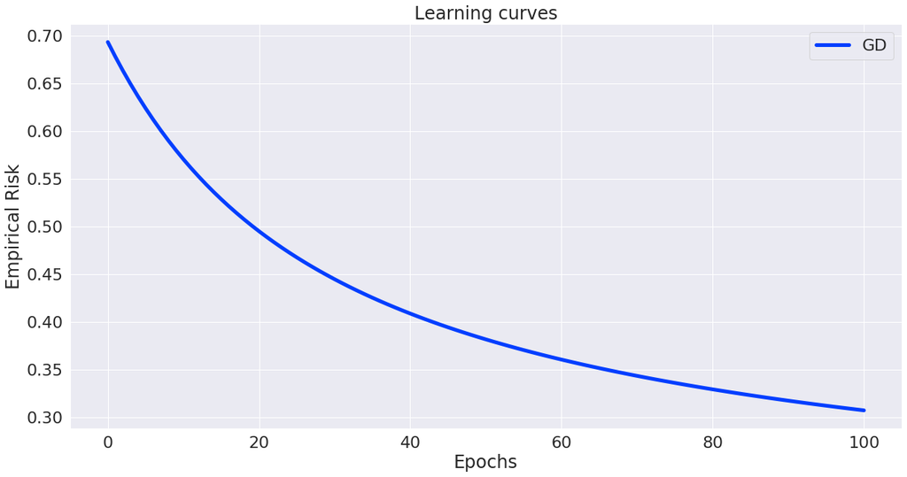

```python
from lib.linear_model import LogisticRegression
from lib.visuals import learning_curve
clf_gd = LogisticRegression(solver='gd',l2=0.01, max_iter=100)
clf_gd.fit(A_train, b_train)


learning_curve(GD=clf_gd)
```

# SGD (Stochastic Gradient Descent)

At iteration k of the SGD algorithm, the following update is executed:

$$ \begin{cases} i \textrm{ chosen randomly in } \{1...n\}\\ x_{k+1} \leftarrow x_{k} - \gamma_k \nabla f_i(x_k) \\ \end{cases} $$

**Question:**

- What stepsize $\gamma_k$ ensures the convergence of this algorithm and under what assumptions?
- Complete **TODO (5)**
- Add your code to **\lib\solvers.py**.

> **Answer:**

> The algorithm converges if we assume that $f$ is $\mu$ strongly convex, differentiable and $L$ smooth, and the stepsize $\gamma$ statisfies $\gamma \leq \frac{1}{k^\alpha}$ Where $\alpha \approx 0.6$. Converges with a sublinear convergence.

```python
def SGD(x0, grad, prox, max_iter, n, L, mu):
    '''
    Parameters
    ----------
    x0: array, shape (nb_features,)
        Initialisation of the solver
    grad: function
        Gradient of the objective function
    max_iter: int
        Number of iterations (i.e. number of descent steps). Note that for GD or SVRG,
        one iteration is one epoch i.e, one pass through the data, while for SGD, SAG and SAGA,
        one iteration uses only one data point.
    n: int
        Dataset size
    L: float
        Smoothness constant of the objective function
    mu: float
        Strong convexity constant of the objective function

    Returns
    -------
    x: array, shape (nb_features,)
        final iterate of the solver after going through n data points
    x_tab: array, shape (nb_features, max_iter)
        table of all the iterates
    '''

    x = np.copy(x0)
    x_tab = np.copy(x)
    for k in range(max_iter):
        t = random.randrange(1, n)
        step = 1/(pow(k+1, 0.6))
        x = x - step*grad(x, t)
        if k % n == 0:  # each completed epoch
            x_tab = np.vstack((x_tab, x))

    return x, x_tab
```

**Question:** Run the code below to test your code.

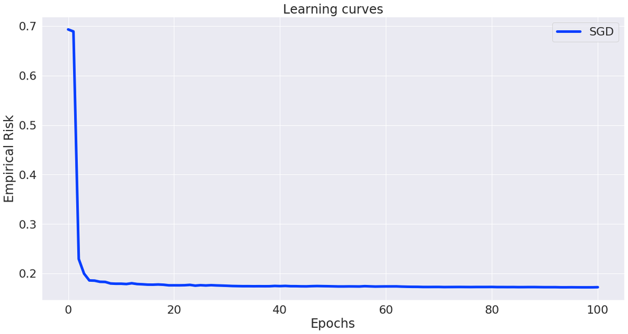

```python
clf_sgd = LogisticRegression(solver='sgd',l2=0.01,max_iter=100*len(b_train))
clf_sgd.fit(A_train, b_train)

learning_curve(SGD=clf_sgd)
```

# SAGA (Stochastic Average Gradient "Amélioré")

SAGA starts by computing a single batch gradient, then at iteration k, the following update is executed:

1. Pick a j uniformly at random.
2. Take $\phi_{j}^{k+1}=x^{k},$ and store $f_{j}^{\prime}\left(\phi_{j}^{k+1}\right)$ in the table. All other entries in the table remain unchanged. The quantity $\phi_{j}^{k+1}$ is not explicitly stored.
3. Update $x$ using $f_{j}^{\prime}\left(\phi_{j}^{k+1}\right), f_{j}^{\prime}\left(\phi_{j}^{k}\right)$ and the table average:

\begin{array}{c} x^{k+1}=x^{k}-\gamma\left[f_{j}^{\prime}\left(\phi_{j}^{k+1}\right)-f_{j}^{\prime}\left(\phi_{j}^{k}\right)+\frac{1}{n} \sum_{i=1}^{n} f_{i}^{\prime}\left(\phi_{i}^{k}\right)\right] \end{array}

**Question:**

- What stepsize $\gamma_k$ ensures the convergence of this algorithm and under what assumptions?
- Complete **TODO (6)**
- Add your code to **\lib\solvers.py**.

> **Answer:** If $f$ is $\mu$ strongly convex, differentiable and $L$ smooth, and for the stepsize $\gamma = \frac{1}{2(\mu n + L)}$, then the algorithm converges with the following convergence rate $$ \mathbb{E}\left\|x^{k}-x^{*}\right\|^{2} \leq\left(1-\frac{\mu}{2(\mu n+L)}\right)^{k}\left[\left\|x^{0}-x^{*}\right\|^{2}+\frac{n}{\mu n+L}\left[f\left(x^{0}\right)-\left\langle f^{\prime}\left(x^{*}\right), x^{0}-x^{*}\right\rangle- f\left(x^{*}\right)\right]\right] $$

```python
def SAGA(x0, grad, prox, max_iter, n, L, mu):
    '''
    Parameters
    ----------
    x0: array, shape (nb_features,)
        Initialisation of the solver
    grad: function
        Gradient of the objective function
    max_iter: int
        Number of iterations (i.e. number of descent steps). Note that for GD or SVRG,
        one iteration is one epoch i.e, one pass through the data, while for SGD, SAG and SAGA,
        one iteration uses only one data point.
    n: int
        Dataset size
    L: float
        Smoothness constant of the objective function
    mu: float
        Strong convexity constant of the objective function

    Returns
    -------
    x: array, shape (nb_features,)
        final iterate of the solver after going through n data points
    x_tab: array, shape (nb_features, max_iter)
        table of all the iterates
    '''
    x = np.copy(x0)
    x_tab = np.copy(x)
    d = len(x)

    A = np.zeros([n, d])
    for i in range(n):
        A[i, :] = grad(x, i)

    step = 1 / (2*(mu*n + L))

    for k in range(max_iter):
        xprev = np.copy(x)

        j = random.randrange(1, n)
        f_grad_phi_k = A[j, :]
        alfa_bar = A.mean(0)
        A[j, :] = grad(x, j)
        x = x - step*(A[j, :] - f_grad_phi_k + alfa_bar)

        if (k % n == 0):  # each completed epoch-n
            x_tab = np.vstack((x_tab, x))

    return x, x_tab
```

**Question:** Run the code below to test your code.

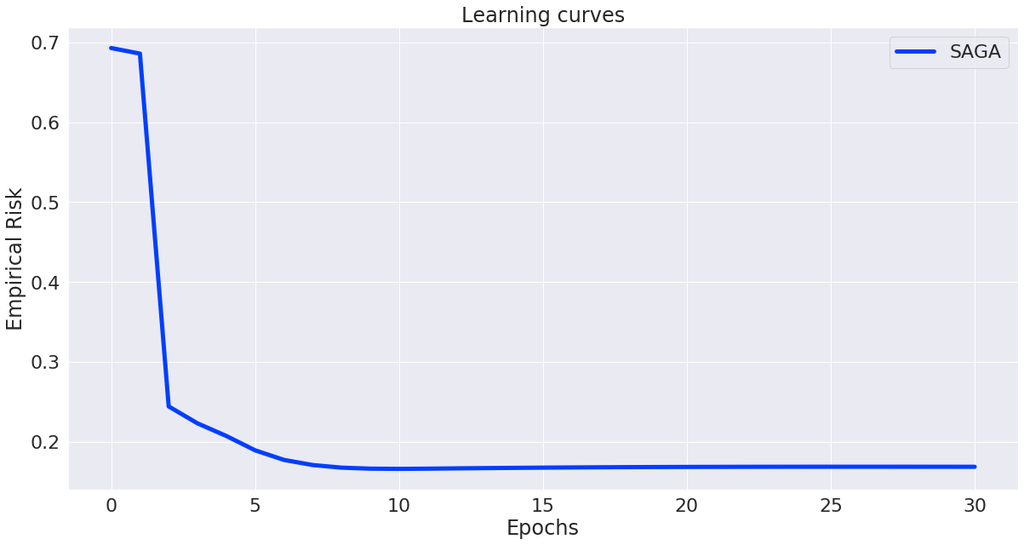

```python
clf_saga = LogisticRegression(solver='saga', l2=0.01,max_iter=30*len(b_train))
clf_saga.fit(A_train, b_train)

learning_curve(SAGA=clf_saga)
```

# SVRG (Stochastic Variance Reduced Gradient)

At iteration k of the SVRG algorithm, we perform the following:

$$ \begin{cases} \textrm{Compute the batch gradient } \nabla f(x_k)\\ \textrm{Initialise }y_0 = x_k\\ \textrm{for m in 0...M-1: } \begin{cases} i \textrm{ chosen randomly in } \{1...n\} \\ y_{m+1} \leftarrow y_{m} - \gamma_k\big(\nabla f_i(y_m) - \nabla f_i(x_k) + \nabla f(x_k)) \end{cases}\\ x_{k+1} \leftarrow y_{M} \end{cases} $$

**Question:**

- What stepsize $\gamma_k$ ensures the convergence of this algorithm and under what assumptions?
- Complete **TODO (7)**
- Add your code to **\lib\solvers.py**.

> **Answer:** We assume that $f_i$ are $L$ smooth and convex, and the function $f$ is $\mu$ strongly convex then as long as we pick $\gamma_k \leq \frac{1}{L}$ we have linear convergence of rate $\mathrm{O}((1 - \frac{\mu}{L})^t)$

```python
def SVRG(x0, grad, max_iter, n, L, mu):
    '''
    Parameters
    ----------
    x0: array, shape (nb_features,)
        Initialisation of the solver
    grad: function
        Gradient of the objective function
    max_iter: int
        Number of iterations (i.e. number of descent steps). Note that for GD or SVRG,
        one iteration is one epoch i.e, one pass through the data, while for SGD, SAG and SAGA,
        one iteration uses only one data point.
    n: int
        Dataset size
    L: float
        Smoothness constant of the objective function
    mu: float
        Strong convexity constant of the objective function

    Returns
    -------
    x: array, shape (nb_features,)
        final iterate of the solver
    x_tab: array, shape (nb_features, max_iter)
        table of all the iterates
    '''
    x = np.copy(x0)
    x_tab = np.copy(x)
    d = len(x)

    step = 1/(2*(mu*n+L))
    for k in range(max_iter):
        #step = 1/(pow(k+1, 0.6))
        G = grad(x)
        y = x

        for i in range(2):
            e = random.randrange(1, n)
            g = grad(y, e)-grad(x, e)+G
            y = y-step*g
        x = y
        x_tab = np.vstack((x_tab, x))

    return x, x_tab
```

**Question:** Run the code below to test your code.

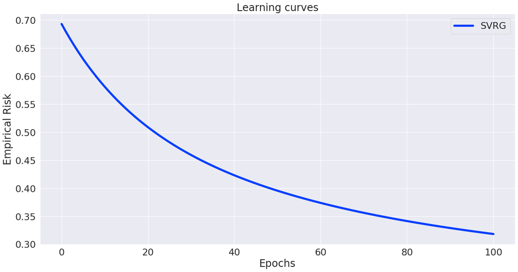

```python
clf_svrg = LogisticRegression(solver='svrg',l2=0.01, max_iter=100)
clf_svrg.fit(A_train, b_train)

learning_curve(SVRG=clf_svrg)
```

# Comparison

**Question:** Run the code below to compare all the methods you've implemented.

```python
epochs = 100
n = len(b_train)

clf_gd   = LogisticRegression(solver='gd', l2=0.01, max_iter=epochs)
clf_sgd  = LogisticRegression(solver='sgd', l2=0.01, max_iter=epochs*n)
clf_saga = LogisticRegression(solver='saga', l2=0.01, max_iter=epochs*n)
clf_svrg = LogisticRegression(solver='svrg', l2=0.01, max_iter=epochs)

clf_gd.fit(A_train, b_train)
clf_sgd.fit(A_train, b_train)
clf_saga.fit(A_train, b_train)

clf_svrg.fit(A_train, b_train)
```

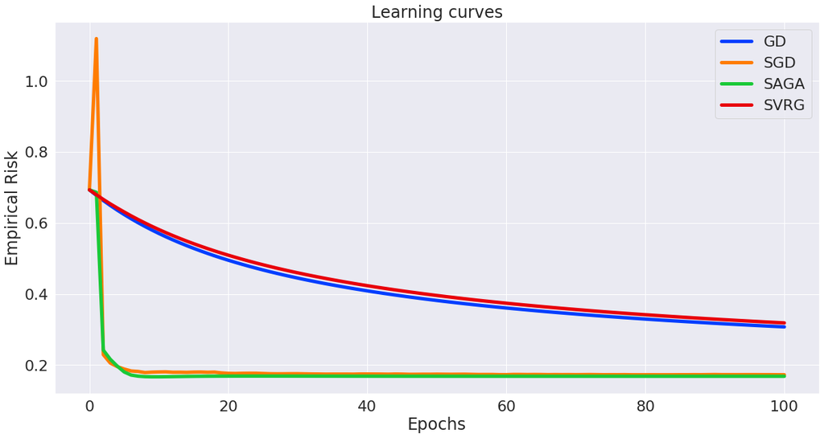

```
gd:	Accuracy on training set: 91.9%
	Accuracy on testing set:  81.8%
sgd:	Accuracy on training set: 95.3%
	Accuracy on testing set:  87.9%
saga:	Accuracy on training set: 94.3%
	Accuracy on testing set:  86.9%
svrg:	Accuracy on training set: 91.9%
	Accuracy on testing set:  80.8%
```

```python
learning_curve(GD=clf_gd, SGD=clf_sgd, SAGA=clf_saga, SVRG=clf_svrg)

for clf, name in zip([clf_gd, clf_sgd, clf_saga, clf_svrg], ['gd', 'sgd','saga', 'svrg']):
    print(name + ':' \
          + "\tAccuracy on training set: {0:0.1f}%".format(100*clf.score(A_train, b_train)))
    print("\tAccuracy on testing set:  {0:0.1f}%".format(100*clf.score(A_test, b_test)))
```

# IV. Regularization

**Question:**

- Rewrite the empirical risk minimization objective with both $L_1$ and $L_2$ regularization (with coefficients $l_1$ and $l_2$).
- Is this objective $\mu$-strongly convex, $L$-smooth, differentiable?
- Complete the **TODO (8)** to account for the new term in the objective.
- Add your code to **lib/linear_model.py**.

Answer: Minimization of the empirical risk $f$ of the $L_2$-regularized logistic regression model, on the dataset $(A_{\textrm{train}},b_{\textrm{train}})$: $$ \begin{aligned} \textrm{min}_{x\in \mathbb{R}^d} \ f(x) \ &= \ \textrm{min}_{x\in \mathbb{R}^d} \ \frac{1}{n_{\textrm{train}}} \sum_{i=1}^{n_{\textrm{train}}} f_i(x) \\ &= \ \textrm{min}_{x\in \mathbb{R}^d}\underbrace{\frac{1}{n_{\textrm{train}}} \sum_{i=1}^{n_{\textrm{train}}} \textrm{LogisticLoss}(b_i, \left\langle a_{i}, x\right\rangle ) + \frac{l_2}{2}\|x\|^{2}_2}_{f(x)} + \underbrace{l_1 \|x\|_1}_{g(x)} \end{aligned} $$ where $l_2,l_1 \ge 0$ are the $L_2$ and $L_1$ regularization coefficients respectively.

```
self._empirical_risk = lambda x: sum(self._logistic_loss(A, b, x))/n \
                                 + self.l2/2.0 * np.linalg.norm(x,2) \
                                 + self.l1 * np.linalg.norm(x,1)
```

#### Definition.

The proximal mapping or the proximal operator for a convex function $h$ is defined as : $$ \operatorname{prox}_{h}(x)=\underset{u}{\operatorname{argmin}}\left(h(u)+\frac{1}{2}\|u-x\|_{2}^{2}\right) $$

#### Examples

- $h(x) = 0$ : $\operatorname{prox}_{h}(x) = x$
- $h(x) = \textrm{I}_{C}(x)$ : $\operatorname{prox}_{h}(x)$ is the projection on the set $C$, $$\operatorname{prox}_{h}(x)=P_{C}(x)=\underset{u \in C}{\operatorname{argmin}}\|u-x\|_{2}^{2}$$
- $h(x) = t \|x\|_1$ : $\operatorname{prox}_{h}(x)$ is shrinkage (soft threshold) operation $$ \operatorname{prox}_{h}(x)_{i}=\left\{\begin{array}{ll} {x_{i}-t} & {x_{i} \geq t} \\ {0} & {\left|x_{i}\right| \leq t} \\ {x_{i}+t} & {x_{i} \leq-t} \end{array}\right. $$

**Question:** Using the $\textrm{prox}_{l_1 \|\cdot\|_1}$ operator, write down the $k^{th}$ step of proximal GD, proximal SGD, proximal SAGA, and proximal SVRG.

> **Answer:**

> Proximal GD : $$ x^{(k)}=\operatorname{prox}_{t_{k} g}\left(x^{(k-1)}-t_{k} \nabla f\left(x^{(k-1)}\right)\right) $$

> Proximal SGD : $$ \begin{cases} i \textrm{ chosen randomly in } \{1...n\}\\ x_{k+1} \leftarrow \operatorname{prox}_{t_{k} h}\left(x^{(k-1)}-t_{k} \nabla f_i\left(x^{(k-1)}\right)\right) \\ \end{cases} $$

**Question:**

- Give a closed-form expression of $\textrm{prox}_{l_1 \|\cdot\|_1}$
- Complete **TODO (9)** (note that you can access the $l_1$ coefficient using **self.l1**).
- Add your code to **\lib\linear_model.py**.

> **Answer:** Let $g = l_1 \|x\|_1$ and $\gamma$ the stepsize of the algorithm. $$ \operatorname{prox}_{\gamma g}(x)_{i}=\left\{\begin{array}{ll} {x_{i}-t} & {x_{i} > l_1 \gamma} \\ {0} & {\left|x_{i}\right| \leq l_1 \gamma} \\ {x_{i}+t} & {x_{i} <-l_1 \gamma} \end{array}\right. $$

```python
def prox(x,stepsize):
    p = np.zeros(n)
    for i in range(n):
        if x[i] < - self.l1*stepsize:
            p[i] = x[i] + self.l1*stepsize
        if x[i] > self.l1*stepsize:
            p[i] = x[i] - self.l1*stepsize
    return p
```

**Question:**

- Add **prox** to the attributes of the solvers (both in the call to **self.solver** in **/lib/linear_model.py** and in **/lib/solvers.py**) as follows:  
  solver(x0, grad, **prox**, self.max_iter, n, L, mu)
- Add a proximal step to all the algorithms in **/lib/solvers.py**.
- Paste one of these algorithms in the cell bellow.

```python
def GD_prox(x0, grad, prox, max_iter, n, L, mu):
    stepsize = 1.0 / L
    x = x0
    x_tab = np.copy(x)

    for k in range(max_iter):
        x = prox(x - stepsize*grad(x), stepsize)
        x_tab = np.vstack((x_tab, x))
    return x, x_tab
```

**Question:** If your proximal gradient descent is correctly implemented, the following cell will plot the support of the solution for various values of $l_1$.

- Interpret the plot and explain what can $L_1$ regularization be used for.

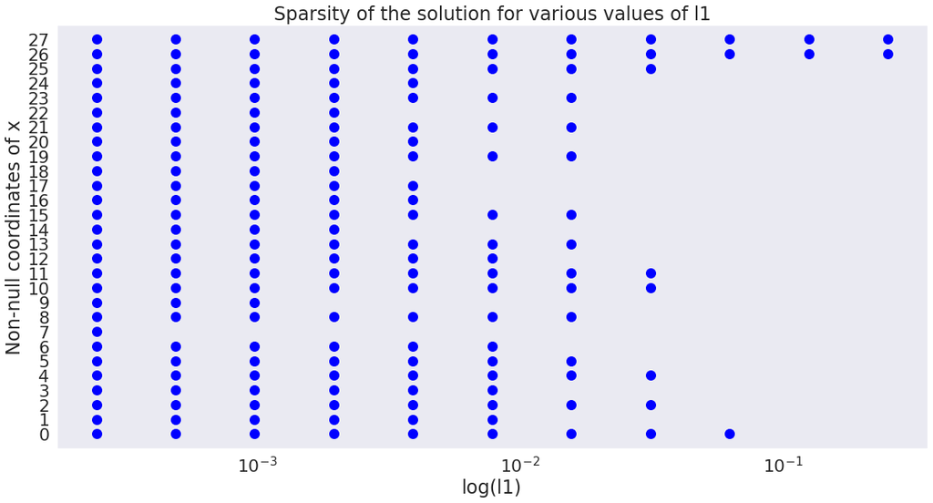

```python
from lib.visuals import l1_regularization_plot

clf = lambda l1: LogisticRegression(solver='gd_prox', l1=l1, l2=0.1, max_iter=1000)

l1_regularization_plot(clf, A_train, b_train)
```

**Question:** The following cell will plot the value of the coordinates of the solution for various values of $l_2$.

- Interpret the plot and explain what can $L_2$ regularization be used for.

> **Answer:** The $l_2$ regularizer is used to avoid the overfitting issue. This is done by reducing MSE ading some bias and reducing variance. Because when using the $l_2$ regularizer we penalize the large coefficients. This way in the plot we see that for good small values of $l_2$ the aplitute of the coefficients decreases.Also if we increase to much the value of $l_2$ we will add to much weight this way we will end up underfitting the model

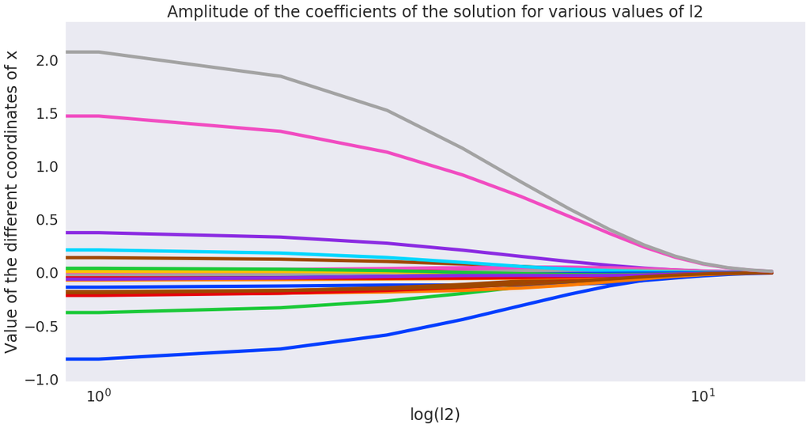

```python
from lib.visuals import l2_regularization_plot

clf = lambda l2: LogisticRegression(solver='gd', l1=0.01, l2=l2, max_iter=1000)

l2_regularization_plot(clf, A_train, b_train)
```

# V. Further development

On this section we will try to prove the convergence of the algorithms we have implemented.

**Proof of convergence of Gradient Descent Algorithm.**

$\textbf{Definition}$ We say tha $f$ is $L$ smooth if its gradint is Lipshitz continuous:

$$\| \nabla f(x) - \nabla f(y) \| \leq L \|x - y\|$$

$\textbf{Lemma 1}$ If $f$ is $L$ smooth then $$ \begin{array}{c} {f\left(x-\frac{1}{L} \nabla f(x)\right)-f(x) \leq-\frac{1}{2 L}\|\nabla f(x)\|_{2}^{2}} \\ \end{array} $$ and $$ f\left(x^{*}\right)-f(x) \leq-\frac{1}{2 L}\|\nabla f(x)\|_{2}^{2} $$ proof: The first inequality follows by inserting $y = x - \frac{1}{L} \nabla f(x)$ in the definition of the smoothness: $$ \begin{aligned} f\left(x-\frac{1}{L} \nabla f(x)\right) & \leq f(x)-\frac{1}{L}\langle\nabla f(x), \nabla f(x)\rangle+\frac{L}{2}\left\|\frac{1}{L} \nabla f(x)\right\|_{2}^{2} \\ &=f(x)-\frac{1}{2 L}\|\nabla f(x)\|_{2}^{2} \end{aligned} $$ Furthermore by using the proved inequality with $f(x^*) \leq f(y)$, $\forall y$, we get: $$ f\left(x^{*}\right)-f(x) \leq f\left(x-\frac{1}{L} \nabla f(x)\right)-f(x) \leq-\frac{1}{2 L}\|\nabla f(x)\|_{2}^{2} $$

Suppose that the function $f$ is $L$ -smooth and $\mu$ -strongly convex. From a given $x_{0} \in \mathbb{R}^{d}$ and $\frac{1}{L} \geq \gamma>0$ we have that the iterates \begin{equation} x^{t+1} = x^{t}-\gamma \nabla f\left(x^{t}\right) \end{equation} converge according to \begin{equation} \left\|x^{t+1}-x^{*}\right\|_{2}^{2} \leq(1-\gamma \mu)^{t+1}\left\| x^{0}-x^{*} \right\|_{2}^{2} \end{equation} In particular, or $\gamma=\frac{1}{L}$ the iterates enjoy a linear convergence with a rate of $\mu / L$.

$\textbf{Proof}$: Starting from the definition of the algorithm we have that \begin{aligned} \left\|x^{t+1}-x^{*}\right\|_{2}^{2} &=\left\|x^{t}-x^{*}-\gamma \nabla f\left(x^{t}\right)\right\|_{2}^{2} \\ &=\left\|x^{t}-x^{*}\right\|_{2}^{2}-2 \gamma\left\langle\nabla f\left(x^{t}\right), x^{t}-x^{*}\right\rangle+\gamma^{2}\left\|\nabla f\left(x^{t}\right)\right\|_{2}^{2} \\ & \leq(1-\gamma \mu)\left\|x^{t}-x^{*}\right\|_{2}^{2}-2 \gamma\left(f\left(x^{t}\right)-f\left(x^{*}\right)\right)+\gamma^{2}\left\|\nabla f\left(x^{t}\right)\right\|_{2}^{2} \\ & \leq(1-\gamma \mu)\left\|x^{t}-x^{*}\right\|_{2}^{2}-2 \gamma\left(f\left(x^{t}\right)-f\left(x^{*}\right)\right)+2 \gamma^{2} L\left(f\left(x^{t}\right)-f\left(x^{*}\right)\right.\\ &=(1-\gamma \mu)\left\|x^{t}-x^{*}\right\|_{2}^{2}-2 \gamma(1-\gamma L)\left(f\left(x^{t}\right)-f\left(x^{*}\right)\right) \end{aligned}

For the first inequality we used the definition of $\mu$-strong convexity, and for the second we Lemma1.

Since $\frac{1}{L} \geq \gamma$ we have that $-2 \gamma(1-\gamma L)$ is negative, and can therefore be removed to give \begin{equation} \left\|x^{t+1}-x^{*}\right\|_{2}^{2} \leq(1-\gamma \mu)\left\|x^{t}-x^{*}\right\|_{2}^{2} \end{equation} By following the recurrence we get the result we wanted to proof.

**Proof of convergence of Stochastic Gradient Descent**

We call the stochastic gradient $g_k$, which is used in the update rule for the SGD algorithm. We have that $f(x)$ is $\mu$-strongly convex, and assume that $\mathbb{E}\left(\left\|g_{k}\right\|^{2}\right) \leq G^{2}$.

Proof: From the strong convexity, we have

\begin{array}{l} {f\left(x^{*}\right)-f\left(x_{k}\right) \geq\left\langle\nabla f\left(x_{k}\right), x^{*}-x_{k}\right\rangle+\frac{l}{2}\left\|x_{k}-x^{*}\right\|^{2}} \\ {f\left(x_{k}\right)-f\left(x^{*}\right) \geq\left\langle\nabla f\left(x^{*}\right), x_{k}-x^{*}\right\rangle+\frac{l}{2}\left\|x_{k}-x^{*}\right\|^{2}} \end{array}

By summarizing the inequalities we get \begin{equation} \left\langle\nabla f\left(x_{k}\right)-\nabla f\left(x^{*}\right), x_{k}-x^{*}\right\rangle=\left\langle\nabla f\left(x_{k}\right), x_{k}-x^{*}\right\rangle \geq l\left\|x_{k}-x^{*}\right\|^{2} \end{equation}

We have

\begin{aligned} \mathbb{E}\left(\left\|x_{k+1}-x^{*}\right\|^{2}\right) &=\mathbb{E}\left(\left\|x_{k}-\gamma_{k} g_{k}-x^{*}\right\|^{2}\right) \\ &=\mathbb{E}\left(\left\|x_{k}-x^{*}\right\|^{2}\right)-2 \gamma_{k} \mathbb{E}\left\langle g_{k}, x_{k}-x^{*}\right\rangle+\gamma_{k}^{2} \mathbb{E}\left(\left\|g_{k}\right\|^{2}\right) \\ & \leq \mathbb{E}\left(\left\|x_{k}-x^{*}\right\|^{2}\right)-2 \gamma_{k} \mathbb{E}\left\langle\nabla f\left(x_{k}\right), x_{k}-x^{*}\right\rangle+\gamma_{k}^{2} G^{2} \end{aligned}

By applying the summarized inequalities above we get \begin{equation} \mathbb{E}\left(\left\|x_{k+1}-x^{*}\right\|^{2}\right) \leq \mathbb{E}\left(\left\|x_{k}-x^{*}\right\|^{2}\right)-2 l \gamma_{k} \mathbb{E}\left(\left\|x_{k}-x^{*}\right\|^{2}\right)+\gamma_{k}^{2} G^{2} \\ =\left(1-2 l \gamma_{k}\right) \mathbb{E}\left(\left\|x_{k}-x^{*}\right\|^{2}\right)+\gamma_{k}^{2} G^{2} \end{equation}

We prove the convergence rate by induction. First we note that \begin{equation} \left\|x_{1}-x^{*}\right\|^{2} \leq \frac{\max \left\{\left\|x_{1}-x^{*}\right\|^{2}, G^{2} / l^{2}\right\}}{1} \end{equation}

Then we assume that the convergence rate holds with $k .$ Next we only need to show that it holds with $k+1 .$ Denote $L=\max \left\|x_{1}-x^{*}\right\|^{2}, G^{2} / l^{2} .$ From the result above we have [ \begin{aligned} \mathbb{E}\left(\left\|x_{k+1}-x^{*}\right\|^{2}\right) & \leq\left(1-\frac{2}{k}\right) \mathbb{E}\left(\left\|x_{k}-x^{*}\right\|^{2}\right)+\frac{1}{l^{2} k^{2}} G^{2} \\ & \leq\left(1-\frac{2}{k}\right) \frac{L}{k}+\frac{1}{l^{2} k^{2}} G^{2} \\ & \leq\left(\frac{1}{k}-\frac{2}{k^{2}}\right) L+\frac{L}{k^{2}} \\ & \leq\left(\frac{1}{k}-\frac{1}{k^{2}}\right) L \\ & \leq \frac{L}{k+1} \end{aligned}

Thus the convergence is proved.

**Result about convergence of SAGA**

The proximal operator $ prox_{\gamma}^h(y) = argmin(h(x)+\frac{1}{2\gamma}|x-y|^2) $ and stepsize of $ \gamma = \frac{1}{2(\mu n + L)} $ lead to $$\mathrm{E}\left[\left\|x^{k}-x^{*}\right\|^{2}\right] \leq\left(1-\frac{\mu}{2\left(\mu^{n}+L\right)}\right)^{k}\left[\left\|x^{0}-x^{*}\right\|^{2}+\frac{n}{\mu n+L}\left[f\left(x^{0}\right)-\left\langle f^{\prime}\left(x^{*}\right), x^{0}-x^{*}\right\rangle- f\left(x^{*}\right)\right]\right]$$ This result comes as a corollary from the following results.

$\textbf{Lemma 2}$. Let $f(x)=\frac{1}{n} \sum_{i=1}^{n} f_{i}(x)$. Suppose each $f_{i}$ is $\mu$ -strongly comvex and has Lipschitz continuous gradients with constant $L$. Then for all $x$ and $x^{*}$ : $$ \left\langle f^{\prime}(x), x^{*}-x\right\rangle \leq \frac{L-\mu}{L}\left[f\left(x^{*}\right)-f(x)\right]-\frac{\mu}{2}\left\|x^{*}-x\right\|^{2} -\frac{1}{2 L n} \sum_{i}\left\|f_{i}^{\prime}\left(x^{*}\right)-f_{i}^{\prime}(x)\right\|^{2}-\frac{\mu}{L}\left\langle f^{\prime}\left(x^{*}\right), x-x^{*}\right\rangle $$

$\textbf{Lemma 3}$. We have that for all $\phi_{i}$ and $x^{*}$ : $$ \frac{1}{n} \sum_{i}\left\|f_{i}^{\prime}\left(\phi_{i}\right)-f_{i}^{\prime}\left(x^{*}\right)\right\|^{2} \leq 2 L\left[\frac{1}{n} \sum_{i} f_{i}\left(\phi_{i}\right)-f\left(x^{*}\right)-\frac{1}{n} \sum_{i}\left\langle f_{i}^{\prime}\left(x^{*}\right), \phi_{i}-x^{*}\right\rangle\right] $$

$\textbf{Lemma 4}$. It holds that for any $\phi_{i}^{k}, x^{*}, x^{k}$ and $\beta>0,$ with $w^{k+1}$ as defined in Equation $I:$ $\begin{aligned} \mathbb{E}\left\|w^{k+1}-x^{k}-\gamma f^{\prime}\left(x^{*}\right)\right\|^{2} \leq & \gamma^{2}\left(1+\beta^{-1}\right) \mathbb{E}\left\|f_{j}^{\prime}\left(\phi_{j}^{k}\right)-f_{j}^{\prime}\left(x^{*}\right)\right\|^{2}+\gamma^{2}(1+\beta) \mathbb{E}\left\|f_{j}^{\prime}\left(x^{k}\right)-f_{j}^{\prime}\left(x^{*}\right)\right\|^{2} \\ &-\gamma^{2} \beta\left\|f^{\prime}\left(x^{k}\right)-f^{\prime}\left(x^{*}\right)\right\|^{2} \end{aligned}$

$\textbf{Theorem 1}$. With $x^{*}$ the optimal solution, define the Lyapunov function $T$ as: $$T^{k}:=T\left(x^{k},\left\{\phi_{i}^{k}\right\}_{i=1}^{n}\right):=\frac{1}{n} \sum_{i} f_{i}\left(\phi_{i}^{k}\right)-f\left(x^{*}\right)-\frac{1}{n} \sum_{i}\left\langle f_{i}^{\prime}\left(x^{*}\right), \phi_{i}^{k}-x^{*}\right\rangle+ c\left\|x^{k}-x^{*}\right\|^{2}$$ Then with $\gamma=\frac{1}{2(\alpha+n+L)}, \quad c=\frac{1}{2 \gamma(1-\gamma \mu) n},$ and $\kappa=\frac{1}{\gamma \mu},$ we have the following expected change in the Lyapunov function between steps of the SAGA algorithm (conditional on $\left.T^{k}\right)$ $$ \mathbb{E}\left[T^{k+1}\right] \leq\left(1-\frac{1}{\kappa}\right) T^{k} $$

Corollary 1. Note that $c\left\|x^{k}-x^{*}\right\|^{2} \leq T^{k},$ and therefore by chaining the expectations, plugging in the constants explicitly and using $\mu(n-0.5) \leq \mu n$ to simplify the expression, we get: $$\mathrm{E}\left[\left\|x^{k}-x^{*}\right\|^{2}\right] \leq\left(1-\frac{\mu}{2\left(\mu^{n}+L\right)}\right)^{k}\left[\left\|x^{0}-x^{*}\right\|^{2}+\frac{n}{\mu n+L}\left[f\left(x^{0}\right)-\left\langle f^{\prime}\left(x^{*}\right), x^{0}-x^{*}\right\rangle- f\left(x^{*}\right)\right]\right]$$

**Result about the convergence of SVRG**

$\textbf{Theorem 1}$ Consider SVRG algorithm we implemented. Assume that all $f_{i}$ are comvex and and smooth and f(x) is $\mu$ strongly convex.Let $x_{*}=\arg \min _{x} f(x)$ Assume that $m$ is sufficiently large so that $$ \alpha=\frac{1}{\mu \gamma(1-2 L \gamma) m}+\frac{2 L \gamma}{1-2 L \gamma}<1 $$ then we have the geometrix convergence in expectation for SVRG: $$\mathbb{E}\left[P\left(\tilde{w}_{s}\right)-P\left(w_{*}\right)\right] \leq \alpha^{*} \mathbb{E}\left[P\left(\bar{w}_{0}\right)-P\left(w_{*}\right)\right]$$

## Prox vs non-prox

#### GD vs GD_PROX

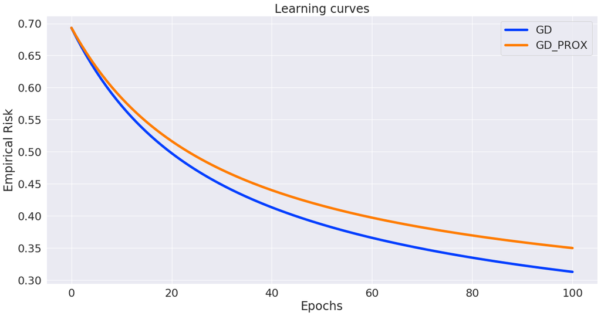

```python
clf_gd = LogisticRegression(solver='gd', l2=0.01, max_iter=100)
clf_gd.fit(A_train, b_train)

clf_gd_prox = LogisticRegression(solver='gd_prox',l1=0.01, l2=0.01, max_iter=100)
clf_gd_prox.fit(A_train, b_train)



learning_curve(GD=clf_gd,GD_PROX=clf_gd_prox)
```

#### SGD vs SGD_PROX

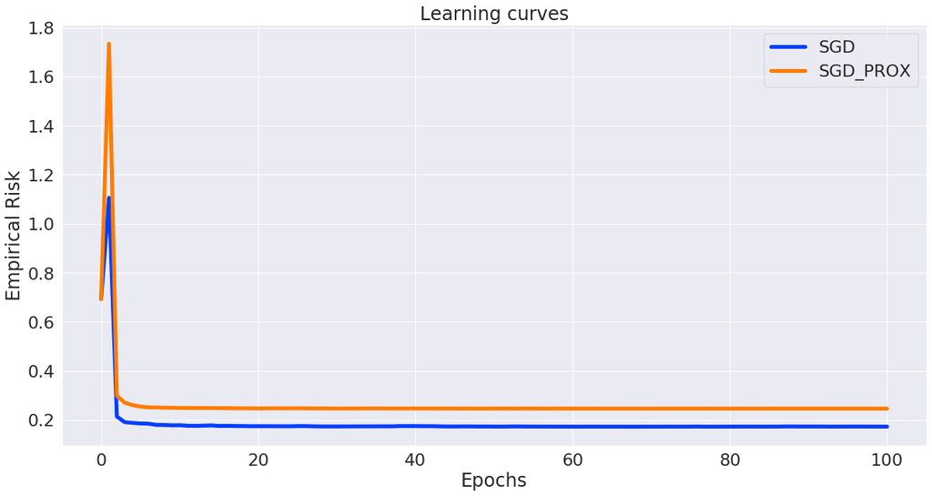

```python
clf_sgd = LogisticRegression(solver='sgd', l2=0.01, max_iter=100*len(b_train))
clf_sgd.fit(A_train, b_train)

clf_sgd_prox = LogisticRegression(solver='sgd_prox',l1=0.01, l2=0.01, max_iter=100*len(b_train))
clf_sgd_prox.fit(A_train, b_train)


learning_curve(SGD=clf_sgd, SGD_PROX = clf_sgd_prox)
```

#### SAGA vs SAGA_PROX

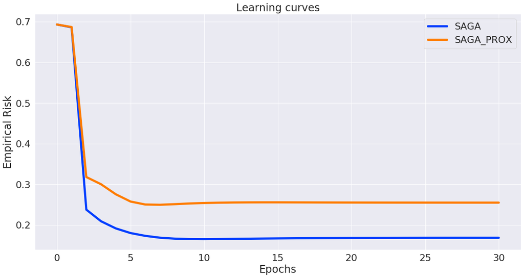

```python
clf_saga = LogisticRegression(solver='saga', l2=0.01, max_iter=30*len(b_train))
clf_saga.fit(A_train, b_train)

clf_saga_prox = LogisticRegression(solver='saga_prox',l1=0.01, l2=0.01, max_iter=30*len(b_train))
clf_saga_prox.fit(A_train, b_train)


learning_curve(SAGA=clf_saga,SAGA_PROX=clf_saga_prox)
```

#### SVRG vs SVRG_PROX

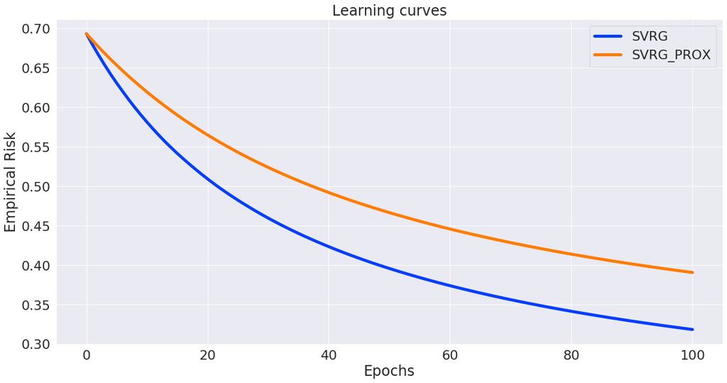

```python
clf_svrg = LogisticRegression(solver='svrg', l2=0.01, max_iter=100)
clf_svrg.fit(A_train, b_train)

clf_svrg_prox = LogisticRegression(solver='svrg_prox',l1=0.01, l2=0.01, max_iter=100)
clf_svrg_prox.fit(A_train, b_train)


learning_curve(SVRG=clf_svrg, SVRG_PROX=clf_svrg_prox)
```

#### All together

```python
epochs = 1000
n = len(b_train)


clf_gd   = LogisticRegression(solver='gd',l2=0.01, max_iter=epochs)
clf_gd_prox = LogisticRegression(solver='gd_prox',l1=0.01,l2=0.01,max_iter=epochs)
clf_sgd  = LogisticRegression(solver='sgd',l2=0.01, max_iter=n*epochs)
clf_sgd_prox = LogisticRegression(solver='sgd_prox',l1=0.01, l2=0.01, max_iter=n*epochs)
clf_saga = LogisticRegression(solver='saga',l2=0.01, max_iter=n*epochs)
clf_saga_prox = LogisticRegression(solver='saga_prox',l1=0.01,l2=0.01,max_iter=n*epochs)
clf_svrg = LogisticRegression(solver='svrg',l2=0.01, max_iter=epochs)
clf_svrg_prox = LogisticRegression(solver='svrg_prox',l1=0.01, l2=0.01, max_iter=epochs)


clf_gd.fit(A_train, b_train)
clf_gd_prox.fit(A_train, b_train)
clf_sgd.fit(A_train, b_train)
clf_sgd_prox.fit(A_train,b_train)
clf_saga.fit(A_train, b_train)
clf_saga_prox.fit(A_train,b_train)
clf_svrg.fit(A_train, b_train)
clf_svrg_prox.fit(A_train, b_train)
```

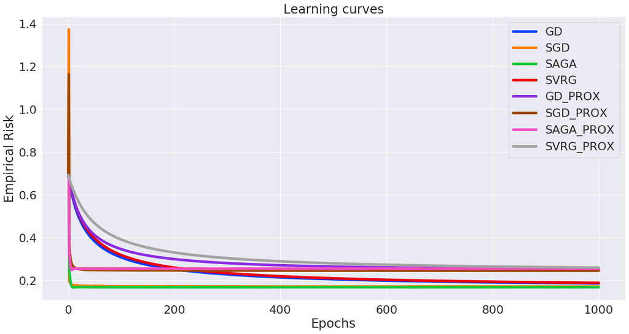

```
gd:	Accuracy on training set: 94.6%
	Accuracy on testing set:  87.9%
sgd:	Accuracy on training set: 94.6%
	Accuracy on testing set:  87.9%
saga:	Accuracy on training set: 94.3%
	Accuracy on testing set:  86.9%
svrg:	Accuracy on training set: 94.3%
	Accuracy on testing set:  88.9%
gd_prox:	Accuracy on training set: 93.2%
	Accuracy on testing set:  89.9%
sgd_prox:	Accuracy on training set: 93.6%
	Accuracy on testing set:  90.9%
saga_prox:	Accuracy on training set: 93.2%
	Accuracy on testing set:  89.9%
svrg_prox:	Accuracy on training set: 92.9%
	Accuracy on testing set:  89.9%
```

```python
learning_curve(GD=clf_gd, SGD=clf_sgd, SAGA=clf_saga, SVRG=clf_svrg, GD_PROX=clf_gd_prox, SGD_PROX=clf_sgd_prox, SAGA_PROX=clf_saga_prox, SVRG_PROX=clf_svrg_prox)

for clf, name in zip([clf_gd, clf_sgd, clf_saga, clf_svrg, clf_gd_prox, clf_sgd_prox, clf_saga_prox, clf_svrg_prox], ['gd', 'sgd','saga', 'svrg', 'gd_prox', 'sgd_prox','saga_prox', 'svrg_prox']):
    print(name + ':' \
          + "\tAccuracy on training set: {0:0.1f}%".format(100*clf.score(A_train, b_train)))
    print("\tAccuracy on testing set:  {0:0.1f}%".format(100*clf.score(A_test, b_test)))
```